# R Notebook

gross income boxplot

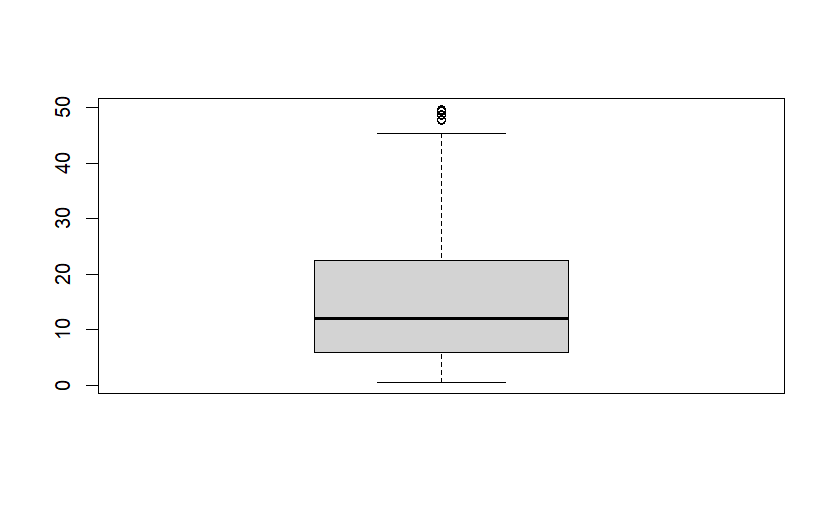

```r
boxplot(dataset$gross.income)
```

The ” Gross income ” boxplot shows many outliers that are very close to each other and needs to be smoothed to remove this noise.

We checked all the numbers to see if there were any outliers. Then, we took out the lines where we found the outliers to make a more accurate dataset that would help us get more accurate results later.

```r
#detict the outliers fot the Total
OutTotal = outlier(dataset$Total, logical =TRUE)
sum(OutTotal)
```

```
[1] 1
```

```r
Find_outlier = which(OutTotal ==TRUE, arr.ind = TRUE)
OutTotal
```

```
   [1] FALSE FALSE FALSE FALSE FALSE FALSE FALSE FALSE FALSE FALSE FALSE FALSE
  [13] FALSE FALSE FALSE FALSE FALSE FALSE FALSE FALSE FALSE FALSE FALSE FALSE
  [25] FALSE FALSE FALSE FALSE FALSE FALSE FALSE FALSE FALSE FALSE FALSE FALSE
  [37] FALSE FALSE FALSE FALSE FALSE FALSE FALSE FALSE FALSE FALSE FALSE FALSE
  [49] FALSE FALSE FALSE FALSE FALSE FALSE FALSE FALSE FALSE FALSE FALSE FALSE
  [61] FALSE FALSE FALSE FALSE FALSE FALSE FALSE FALSE FALSE FALSE FALSE FALSE
  [73] FALSE FALSE FALSE FALSE FALSE FALSE FALSE FALSE FALSE FALSE FALSE FALSE
  [85] FALSE FALSE FALSE FALSE FALSE FALSE FALSE FALSE FALSE FALSE FALSE FALSE
  [97] FALSE FALSE FALSE FALSE FALSE FALSE FALSE FALSE FALSE FALSE FALSE FALSE
 [109] FALSE FALSE FALSE FALSE FALSE FALSE FALSE FALSE FALSE FALSE FALSE FALSE
 [121] FALSE FALSE FALSE FALSE FALSE FALSE FALSE FALSE FALSE FALSE FALSE FALSE
 [133] FALSE FALSE FALSE FALSE FALSE FALSE FALSE FALSE FALSE FALSE FALSE FALSE
 [145] FALSE FALSE FALSE FALSE FALSE FALSE FALSE FALSE FALSE FALSE FALSE FALSE
 [157] FALSE FALSE FALSE FALSE FALSE FALSE FALSE FALSE FALSE FALSE FALSE FALSE
 [169] FALSE FALSE FALSE FALSE FALSE FALSE FALSE FALSE FALSE FALSE FALSE FALSE
```

[output cut: 69 more lines]

```r
Find_outlier
```

```
[1] 351
```

```r
#remove the  fot the Total
dataset= dataset[-Find_outlier,]
```

```r
#detict the outliers for the cogs
OutCogs = outlier(dataset$cogs, logical =TRUE)
sum(OutCogs)
```

```
[1] 1
```

```r
Find_outlier = which(OutCogs ==TRUE, arr.ind = TRUE)
OutCogs
```

```
  [1] FALSE FALSE FALSE FALSE FALSE FALSE FALSE FALSE FALSE FALSE FALSE FALSE
 [13] FALSE FALSE FALSE FALSE FALSE FALSE FALSE FALSE FALSE FALSE FALSE FALSE
 [25] FALSE FALSE FALSE FALSE FALSE FALSE FALSE FALSE FALSE FALSE FALSE FALSE
 [37] FALSE FALSE FALSE FALSE FALSE FALSE FALSE FALSE FALSE FALSE FALSE FALSE
 [49] FALSE FALSE FALSE FALSE FALSE FALSE FALSE FALSE FALSE FALSE FALSE FALSE
 [61] FALSE FALSE FALSE FALSE FALSE FALSE FALSE FALSE FALSE FALSE FALSE FALSE
 [73] FALSE FALSE FALSE FALSE FALSE FALSE FALSE FALSE FALSE FALSE FALSE FALSE
 [85] FALSE FALSE FALSE FALSE FALSE FALSE FALSE FALSE FALSE FALSE FALSE FALSE
 [97] FALSE FALSE FALSE FALSE FALSE FALSE FALSE FALSE FALSE FALSE FALSE FALSE
[109] FALSE FALSE FALSE FALSE FALSE FALSE FALSE FALSE FALSE FALSE FALSE FALSE
[121] FALSE FALSE FALSE FALSE FALSE FALSE FALSE FALSE FALSE FALSE FALSE FALSE
[133] FALSE FALSE FALSE FALSE FALSE FALSE FALSE FALSE FALSE FALSE FALSE FALSE
[145] FALSE FALSE FALSE FALSE FALSE FALSE FALSE FALSE FALSE FALSE FALSE FALSE
[157] FALSE FALSE FALSE FALSE FALSE FALSE FALSE FALSE FALSE FALSE FALSE  TRUE
[169] FALSE FALSE FALSE FALSE FALSE FALSE FALSE FALSE FALSE FALSE FALSE FALSE
```

[output cut: 69 more lines]

```r
Find_outlier
```

```
[1] 168
```

```r
#remove the outlier for the cogs
dataset= dataset[-Find_outlier,]
```

```r
#detict the outliers for the gross income
OutGrossIncome = outlier(dataset$gross.income, logical =TRUE)
sum(OutGrossIncome)
```

```
[1] 1
```

```r
Find_outlier = which(OutGrossIncome ==TRUE, arr.ind = TRUE)
OutGrossIncome
```

```
  [1] FALSE FALSE FALSE FALSE FALSE FALSE FALSE FALSE FALSE FALSE FALSE FALSE
 [13] FALSE FALSE FALSE FALSE FALSE FALSE FALSE FALSE FALSE FALSE FALSE FALSE
 [25] FALSE FALSE FALSE FALSE FALSE FALSE FALSE FALSE FALSE FALSE FALSE FALSE
 [37] FALSE FALSE FALSE FALSE FALSE FALSE FALSE FALSE FALSE FALSE FALSE FALSE
 [49] FALSE FALSE FALSE FALSE FALSE FALSE FALSE FALSE FALSE FALSE FALSE FALSE
 [61] FALSE FALSE FALSE FALSE FALSE FALSE FALSE FALSE FALSE FALSE FALSE FALSE
 [73] FALSE FALSE FALSE FALSE FALSE FALSE FALSE FALSE FALSE FALSE FALSE FALSE
 [85] FALSE FALSE FALSE FALSE FALSE FALSE FALSE FALSE FALSE FALSE FALSE FALSE
 [97] FALSE FALSE FALSE FALSE FALSE FALSE FALSE FALSE FALSE FALSE FALSE FALSE
[109] FALSE FALSE FALSE FALSE FALSE FALSE FALSE FALSE FALSE FALSE FALSE FALSE
[121] FALSE FALSE FALSE FALSE FALSE FALSE FALSE FALSE FALSE FALSE FALSE FALSE
[133] FALSE FALSE FALSE FALSE FALSE FALSE FALSE FALSE FALSE FALSE FALSE FALSE
[145] FALSE FALSE FALSE FALSE FALSE FALSE FALSE FALSE FALSE FALSE FALSE FALSE
[157] FALSE FALSE FALSE FALSE FALSE FALSE FALSE FALSE FALSE FALSE FALSE FALSE
[169] FALSE FALSE FALSE FALSE FALSE FALSE FALSE FALSE FALSE FALSE FALSE FALSE
```

[output cut: 69 more lines]

```r
Find_outlier
```

```
[1] 556
```

```r
#remove the outlier for the gross income
dataset= dataset[-Find_outlier,]
```

```r
#detict the outliers the Quantity
OutQuantity = outlier(dataset$Quantity, logical =TRUE)
sum(OutQuantity)
```

```
[1] 116
```

```r
Find_outlier = which(OutQuantity ==TRUE, arr.ind = TRUE)
OutQuantity
```

```
  [1] FALSE FALSE FALSE FALSE FALSE FALSE FALSE  TRUE FALSE FALSE FALSE FALSE
 [13] FALSE  TRUE  TRUE FALSE FALSE FALSE FALSE FALSE FALSE FALSE FALSE FALSE
 [25] FALSE FALSE FALSE FALSE FALSE FALSE FALSE FALSE FALSE FALSE FALSE FALSE
 [37] FALSE FALSE FALSE FALSE FALSE FALSE FALSE FALSE FALSE FALSE FALSE FALSE
 [49] FALSE  TRUE FALSE FALSE FALSE FALSE FALSE FALSE FALSE FALSE  TRUE FALSE
 [61] FALSE FALSE FALSE  TRUE FALSE  TRUE FALSE FALSE  TRUE FALSE  TRUE  TRUE
 [73] FALSE FALSE FALSE  TRUE FALSE FALSE  TRUE FALSE FALSE FALSE FALSE FALSE
 [85] FALSE FALSE FALSE FALSE FALSE FALSE FALSE  TRUE FALSE FALSE FALSE FALSE
 [97]  TRUE FALSE FALSE FALSE FALSE FALSE FALSE FALSE FALSE  TRUE FALSE FALSE
[109] FALSE  TRUE FALSE FALSE FALSE FALSE FALSE FALSE FALSE FALSE  TRUE FALSE
[121] FALSE FALSE FALSE FALSE FALSE FALSE FALSE FALSE FALSE FALSE FALSE FALSE
[133] FALSE FALSE FALSE FALSE FALSE FALSE  TRUE FALSE  TRUE  TRUE  TRUE FALSE
[145] FALSE FALSE  TRUE FALSE FALSE FALSE FALSE FALSE FALSE FALSE FALSE FALSE
[157] FALSE FALSE FALSE FALSE FALSE FALSE FALSE FALSE  TRUE FALSE  TRUE FALSE
[169] FALSE FALSE FALSE FALSE FALSE FALSE FALSE FALSE FALSE FALSE FALSE FALSE
```

[output cut: 69 more lines]

```r
Find_outlier
```

```
  [1]   8  14  15  50  59  64  66  69  71  72  76  79  92  97 106 110 119 139
 [19] 141 142 143 147 165 167 182 203 207 234 251 263 267 269 276 278 279 290
 [37] 294 314 349 355 356 367 386 390 392 409 421 428 445 456 457 460 464 471
 [55] 477 480 482 483 485 490 492 527 531 545 559 563 564 569 586 600 612 621
 [73] 625 628 633 647 650 661 668 672 676 685 690 697 700 725 733 735 744 750
 [91] 756 758 759 790 795 807 809 826 827 836 851 870 878 880 885 887 904 907
[109] 930 940 956 968 986 989 991 994
```

```r
#remove the outlier the Quantity
dataset= dataset[-Find_outlier,]
```

```r
#detict the outliers for the unit price
OutUnitPrice = outlier(dataset$Unit.price, logical =TRUE)
sum(OutUnitPrice)
```

```
[1] 1
```

```r
Find_outlier = which(OutUnitPrice ==TRUE, arr.ind = TRUE)
OutUnitPrice
```

```
  [1] FALSE FALSE FALSE FALSE FALSE FALSE FALSE FALSE FALSE FALSE FALSE FALSE
 [13] FALSE FALSE FALSE FALSE FALSE FALSE FALSE FALSE FALSE FALSE FALSE FALSE
 [25] FALSE FALSE FALSE FALSE FALSE FALSE FALSE FALSE FALSE FALSE FALSE FALSE
 [37] FALSE FALSE FALSE FALSE FALSE FALSE FALSE FALSE FALSE FALSE FALSE FALSE
 [49] FALSE FALSE FALSE FALSE FALSE FALSE FALSE FALSE FALSE FALSE FALSE FALSE
 [61] FALSE FALSE FALSE FALSE FALSE FALSE FALSE FALSE FALSE FALSE FALSE FALSE
 [73] FALSE FALSE FALSE FALSE FALSE FALSE FALSE FALSE FALSE FALSE FALSE FALSE
 [85] FALSE FALSE FALSE FALSE FALSE FALSE FALSE FALSE FALSE FALSE FALSE FALSE
 [97] FALSE FALSE FALSE FALSE FALSE FALSE FALSE FALSE FALSE FALSE FALSE FALSE
[109] FALSE FALSE FALSE FALSE FALSE FALSE FALSE FALSE FALSE FALSE FALSE FALSE
[121] FALSE FALSE FALSE FALSE FALSE FALSE FALSE FALSE FALSE FALSE FALSE FALSE
[133] FALSE FALSE FALSE FALSE FALSE FALSE FALSE FALSE FALSE FALSE FALSE FALSE
[145] FALSE FALSE FALSE FALSE FALSE FALSE FALSE FALSE FALSE FALSE FALSE FALSE
[157] FALSE FALSE FALSE FALSE FALSE FALSE FALSE FALSE FALSE FALSE FALSE FALSE
[169] FALSE FALSE FALSE FALSE FALSE FALSE FALSE FALSE FALSE FALSE FALSE FALSE
```

[output cut: 59 more lines]

```r
Find_outlier
```

```
[1] 832
```

```r
#remove the outlier for the unit price
dataset= dataset[-Find_outlier,]
```

dataset after removing the outliers

```r
summary(dataset)
```

```
     City           Customer.type         Gender          Product.line
 Length:880         Length:880         Length:880         Length:880
 Class :character   Class :character   Class :character   Class :character
 Mode  :character   Mode  :character   Mode  :character   Mode  :character



   Unit.price       Quantity         Total            Date
 Min.   :10.13   Min.   :1.000   Min.   : 10.68   Length:880
 1st Qu.:32.85   1st Qu.:3.000   1st Qu.:103.81   Class :character
 Median :55.05   Median :5.000   Median :221.95   Mode  :character
 Mean   :55.68   Mean   :4.901   Mean   :287.46
 3rd Qu.:77.94   3rd Qu.:7.000   3rd Qu.:416.52
 Max.   :99.96   Max.   :9.000   Max.   :944.62
     Time             Payment               cogs         gross.income
 Length:880         Length:880         Min.   : 10.17   Min.   : 0.5085
 Class :character   Class :character   1st Qu.: 98.87   1st Qu.: 4.9435
 Mode  :character   Mode  :character   Median :211.38   Median :10.5690
                                       Mean   :273.77   Mean   :13.6885
                                       3rd Qu.:396.69   3rd Qu.:19.8345
                                       Max.   :899.64   Max.   :44.9820
     Rating
 Min.   : 4.000
 1st Qu.: 5.575
 Median : 7.000
 Mean   : 6.997
 3rd Qu.: 8.500
 Max.   :10.000
```